# Prediction Assignment Writeup

Anirban Chakraborty

3 January 2018

# **Introduction**

Using devices such as *Jawbone Up*, *Nike FuelBand*, and *Fitbit* it is now possible to collect a large amount of data about personal activity relatively inexpensively. These type of devices are part of the quantified self movement – a group of enthusiasts who take measurements about themselves regularly to improve their health, to find patterns in their behavior, or because they are tech geeks. One thing that people regularly do is quantify how much of a particular activity they do, but they rarely quantify how well they do it. In this project, your goal will be to use data from accelerometers on the belt, forearm, arm, and dumbell of 6 participants. They were asked to perform barbell lifts correctly and incorrectly in 5 different ways. More information is available from the website here: http://groupware.les.inf.puc-rio.br/har (see the section on the Weight Lifting Exercise Dataset).

## Data

The training data are available here: https://d396qusza40orc.cloudfront.net/predmachlearn/pml-training.csv. The test data are available here: https://d396qusza40orc.cloudfront.net/predmachlearn/pml-testing.csv

## Goal

The goal of this project is to predict the manner in which they did the exercise. This is the “classe” variable in the training set. I will create this report describing how the model has been built, how cross validation has been used, what is the expected out of sample error is, and why I made the choices I did.

### Getting and Loading data

```r
set.seed(12345)
# download.file("http://d396qusza40orc.cloudfront.net/predmachlearn/pml-training.csv", destfile = "pml-training.csv")
# download.file("http://d396qusza40orc.cloudfront.net/predmachlearn/pml-testing.csv", destfile = "pml-testing.csv")
training <- read.csv("pml-training.csv")
testing  <- read.csv("pml-testing.csv")
```

Partitioning the training dataset into training and cross-validation sets

```r
inTrain <- createDataPartition(training$classe, p = 0.6, list = FALSE)
myTraining <- training[inTrain,]
myTesting  <- training[-inTrain,]
dim(myTraining)
```

[1] 11776 160

```r
dim(myTesting)
```

[1] 7846 160

### Cleaning the data

Removing NearZeroVariance variables

```r
nzv <- nearZeroVar(myTraining, saveMetrics = TRUE)
myTraining <- myTraining[,nzv$nzv == FALSE]

nzv <- nearZeroVar(myTesting, saveMetrics = TRUE)
myTesting <- myTesting[,nzv$nzv == FALSE]
```

Removing the first column of myTraining dataset

```r
myTraining <- myTraining[c(-1)]
```

```r
trainingV3 <- myTraining
for(i in 1:length(myTraining)) {
    if(sum(is.na(myTraining[,i]))/ nrow(myTraining) >= 0.7) {
        for(j in 1:length(trainingV3)) {
            if(length(grep(names(myTraining[i]), names(trainingV3)[j])) == 1) {
                trainingV3 <- trainingV3[, -j]
            }
        }
    }
}
myTraining <- trainingV3
```

Transform myTraining and testing datasets

```r
clean1 <- colnames(myTraining)
clean2 <- colnames(myTraining[, -58])   #removing classe column
myTesting <- myTesting[clean1]
testing <- testing[clean2]
dim(myTesting)
```

[1] 7846 58

```r
dim(testing)
```

[1] 20 57

Coerce the data into same type

```r
for (i in 1:length(testing)) {
    for (j in 1:length(myTraining)) {
        if(length(grep(names(myTraining[i]), names(testing)[j])) == 1) {
            class(testing[j]) <- class(myTraining[i])
        }
    }
}

testing <- rbind(myTraining[2, -58], testing)
testing <- testing[-1, ]
```

### Prediction with Decision Trees

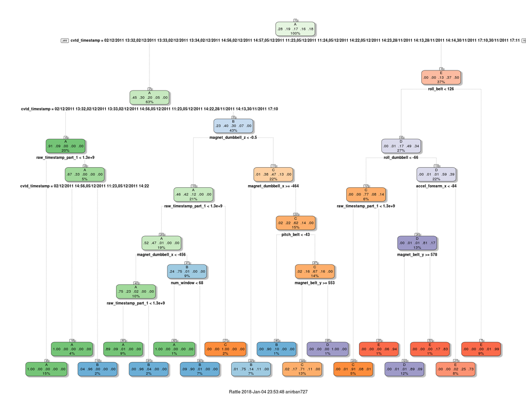

```r
set.seed(12345)
modFitA1 <- rpart(classe ~ ., data = myTraining, method = "class")
fancyRpartPlot(modFitA1)
```

```r
predictionsA1 <- predict(modFitA1, myTesting, type = "class")
cmtree <- confusionMatrix(predictionsA1, myTesting$classe)
cmtree
```

Confusion Matrix and Statistics

```
      Reference
```

Prediction A B C D E A 2150 60 7 1 0 B 61 1260 69 64 0 C 21 188 1269 143 4 D 0 10 14 857 78 E 0 0 9 221 1360

Overall Statistics

```
           Accuracy : 0.8789
             95% CI : (0.8715, 0.8861)
No Information Rate : 0.2845
P-Value [Acc > NIR] : < 2.2e-16

              Kappa : 0.8468
```

Mcnemar’s Test P-Value : NA

Statistics by Class:

```
                 Class: A Class: B Class: C Class: D Class: E
```

Sensitivity 0.9633 0.8300 0.9276 0.6664 0.9431 Specificity 0.9879 0.9693 0.9450 0.9845 0.9641 Pos Pred Value 0.9693 0.8666 0.7809 0.8936 0.8553 Neg Pred Value 0.9854 0.9596 0.9841 0.9377 0.9869 Prevalence 0.2845 0.1935 0.1744 0.1639 0.1838 Detection Rate 0.2740 0.1606 0.1617 0.1092 0.1733 Detection Prevalence 0.2827 0.1853 0.2071 0.1222 0.2027 Balanced Accuracy 0.9756 0.8997 0.9363 0.8254 0.9536

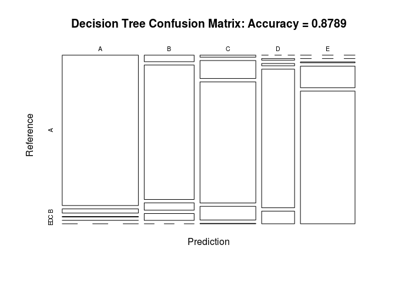

```r
plot(cmtree$table, col = cmtree$byClass, main = paste("Decision Tree Confusion Matrix: Accuracy =", round(cmtree$overall['Accuracy'], 4)))
```

### Prediction with Random Forest

```r
set.seed(12345)
modFitB1 <- randomForest(classe ~ ., data = myTraining)
predictionsB1 <- predict(modFitB1, myTesting, type = "class")
cmrf <- confusionMatrix(predictionsB1, myTesting$classe)
cmrf
```

Confusion Matrix and Statistics

```
      Reference
```

Prediction A B C D E A 2231 2 0 0 0 B 1 1516 0 0 0 C 0 0 1367 3 0 D 0 0 1 1282 1 E 0 0 0 1 1441

Overall Statistics

```
           Accuracy : 0.9989
             95% CI : (0.9978, 0.9995)
No Information Rate : 0.2845
P-Value [Acc > NIR] : < 2.2e-16

              Kappa : 0.9985
```

Mcnemar’s Test P-Value : NA

Statistics by Class:

```
                 Class: A Class: B Class: C Class: D Class: E
```

Sensitivity 0.9996 0.9987 0.9993 0.9969 0.9993 Specificity 0.9996 0.9998 0.9995 0.9997 0.9998 Pos Pred Value 0.9991 0.9993 0.9978 0.9984 0.9993 Neg Pred Value 0.9998 0.9997 0.9998 0.9994 0.9998 Prevalence 0.2845 0.1935 0.1744 0.1639 0.1838 Detection Rate 0.2843 0.1932 0.1742 0.1634 0.1837 Detection Prevalence 0.2846 0.1933 0.1746 0.1637 0.1838 Balanced Accuracy 0.9996 0.9993 0.9994 0.9983 0.9996

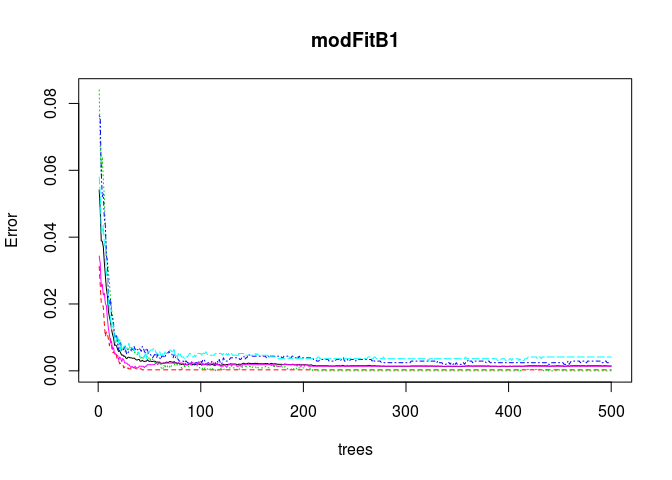

```r
plot(modFitB1)
```

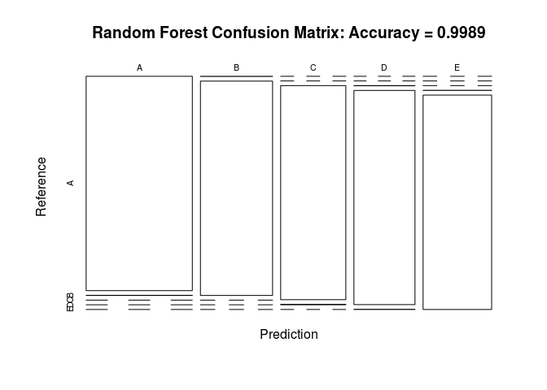

```r
plot(cmrf$table, col = cmtree$byClass, main = paste("Random Forest Confusion Matrix: Accuracy =", round(cmrf$overall['Accuracy'], 4)))
```

### Prediction with Generalized Boosted Regression

```r
set.seed(12345)
fitControl <- trainControl(method = "repeatedcv", number = 5, repeats = 1)
gbmFit1 <- train(classe ~., data = myTraining, method = "gbm", trControl = fitControl, verbose = FALSE)

gbmPredTest <- predict(gbmFit1, newdata = myTesting)
gbmAccuracyTest <- confusionMatrix(gbmPredTest, myTesting$classe)
gbmAccuracyTest
```

Confusion Matrix and Statistics

```
      Reference
```

Prediction A B C D E A 2231 5 0 0 0 B 1 1512 0 0 0 C 0 1 1362 5 0 D 0 0 6 1272 0 E 0 0 0 9 1442

Overall Statistics

```
           Accuracy : 0.9966
             95% CI : (0.995, 0.9977)
No Information Rate : 0.2845
P-Value [Acc > NIR] : < 2.2e-16

              Kappa : 0.9956
```

Mcnemar’s Test P-Value : NA

Statistics by Class:

```
                 Class: A Class: B Class: C Class: D Class: E
```

Sensitivity 0.9996 0.9960 0.9956 0.9891 1.0000 Specificity 0.9991 0.9998 0.9991 0.9991 0.9986 Pos Pred Value 0.9978 0.9993 0.9956 0.9953 0.9938 Neg Pred Value 0.9998 0.9991 0.9991 0.9979 1.0000 Prevalence 0.2845 0.1935 0.1744 0.1639 0.1838 Detection Rate 0.2843 0.1927 0.1736 0.1621 0.1838 Detection Prevalence 0.2850 0.1928 0.1744 0.1629 0.1849 Balanced Accuracy 0.9993 0.9979 0.9973 0.9941 0.9993

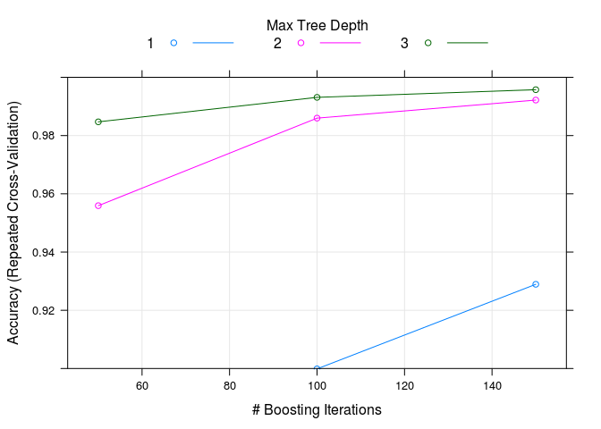

```r
plot(gbmFit1, ylim = c(0.9,1))
```